# Extracting knowledge trees

December 6, 2017

## Introduction

- Objective
  - To extract hierarchical structure of articles for a field (say, Mathematics, Physics..)
- Why?
  - Individual learning is still hierarchical
  - Can be used to create structured curriculum content with just resources available on the web
  - Identify gaps in information on the web

## Data

- HTML Physics textbook (http://hyperphysics.phy-astr.gsu.edu/)
  - More complete hyperlink structure
  - Smaller network, easier to work with
- Scraping to get the hyperlinks for every page

```r
library(rvest)
library(xml2)
```

Looking at the links for the page "acceleration"

```r
url <- "http://hyperphysics.phy-astr.gsu.edu/hbase/acca.html#c1"
webpage <- read_html(url)
nodes <- html_nodes(webpage, "a")
titles <- html_text(nodes)
links <- html_attr(nodes, "href")
```

## Data

```r
head(links[-1])
```

```
## [1] "vel2.html#c1"     "vect.html#veccon" "vect.html#vec1"
## [4] "units.html#uni4"  "deriv.html#c1"    "mot.html#mot1"
```

```r
head(titles[-1])
```

```
## [1] "velocity"
## [2] "vector"
## [3] "vector addition"
## [4] "units"
## [5] "derivative"
## [6] "Motion equations when acceleration is constant"
```

## Network

- ~20 mins and a lot of cleaning later, we have the complete hyperlink sturucture

```r
head(page_details, 4)  ## Vetrex and Vertex attribute (title)
```

```
##          url        title
## 1  acca.html acceleration
## 2  vel2.html     velocity
## 3  vect.html       vector
## 4 units.html        units
```

```r
head(edge_list, 4)  ## Edgelist
```

```
##    from_url     to_url
## 1 acca.html  vel2.html
## 2 acca.html  vect.html
## 3 acca.html units.html
## 4 acca.html deriv.html
```

## Network Statistics

```
## [1] "No. of Nodes:  3747"
```

```
## [1] "No. of Edges:  27817"
```

```
## [1] "Density:  0.00198"
```

```
## [1] "Mean In-Degree:  7.4238"
```

```
## [1] "Mean Out-Degree:  7.4238"
```

```
## [1] "Network Centralization:  0.275"
```

```
## [1] "Average Geodesic Distance:  6.093"
```

## Degree Distribution

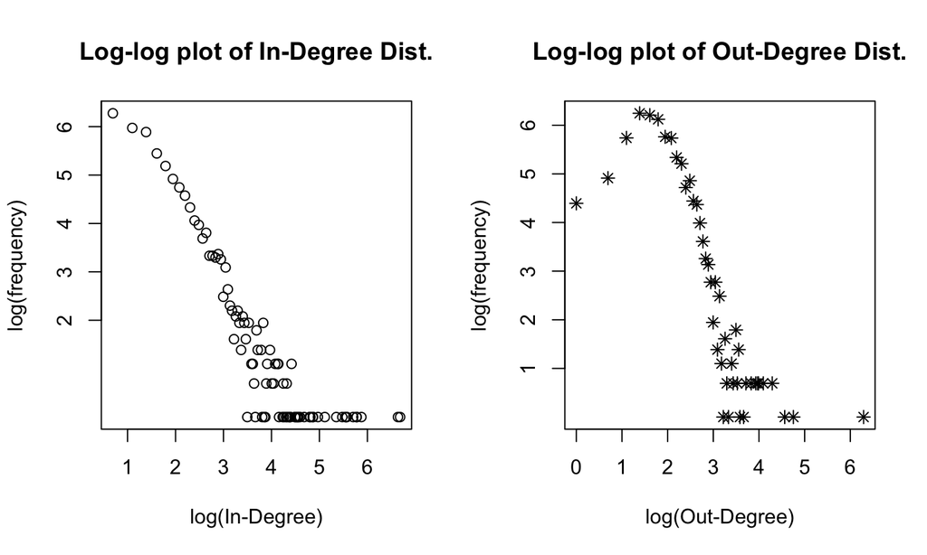

## Geodesic distance Distribution

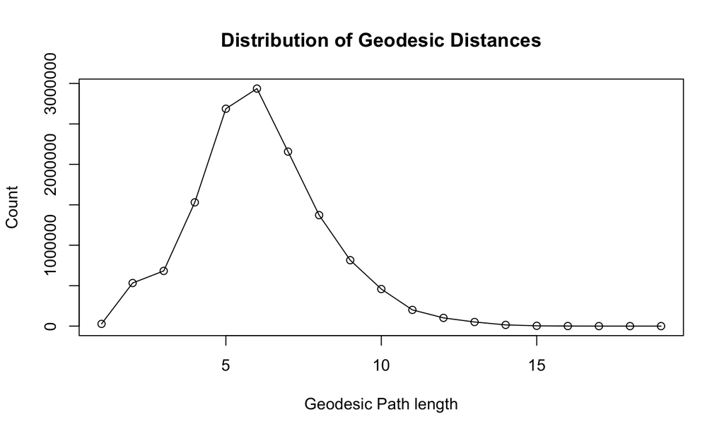

## Hierarchy Extraction

- Looking at a random tree-structure, we can see that greater centrality corresponds to the higher level in the hierarchy

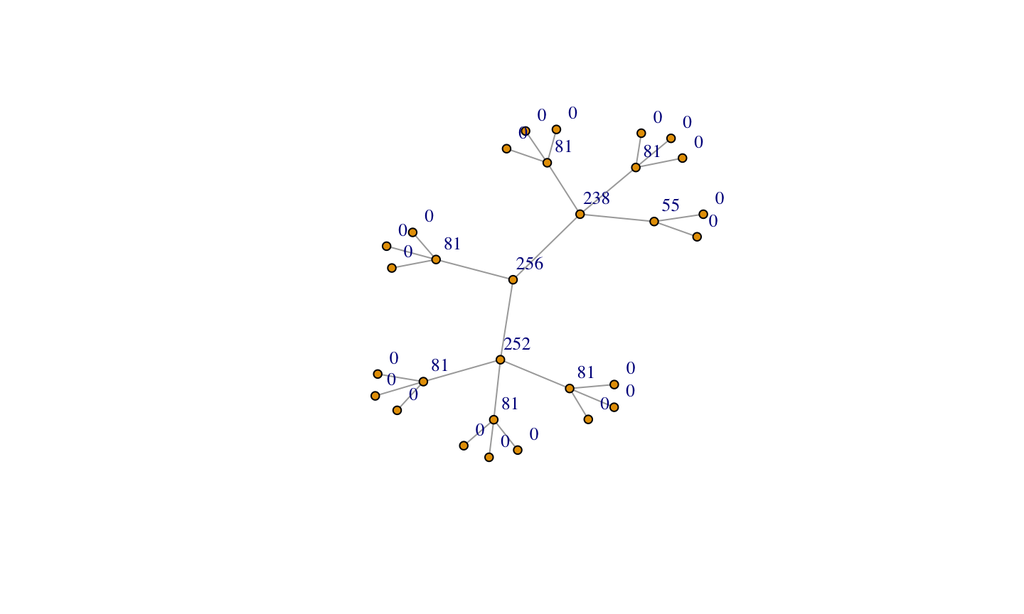

## Hierarchy Extraction

1. Define a suitable hierarchy score for each node
2. Compare scores for 2 neighboring nodes (in the underlying undirected network)
   1. If ratio of scores is between a lower and an upper threshold
   2. Then, the node with the higher score is higher in the hierarchy
3. Cutoff eliminates
   1. relations between two highly different nodes
   2. relations where the nodes are too similar (i.e. ratio ~1)
   3. edges to leaf nodes in the hierarchy

## Still to do/Challenges

- plotting better to visualise easily
- full network validation measure
- sensitivity to cutoff
- take a dig at Wiki network